# Ecological Niche Modeling — A Beginner’s Field Guide

## 3.7 Predict suitability everywhere

Now we take each ellipsoid and ask, *for every pixel of the map, how well do its conditions match the niche?* That is what **`predict()`** does. Behind the scenes it measures the **Mahalanobis distance** from each pixel to the niche’s centre and turns that distance into a **suitability** score.

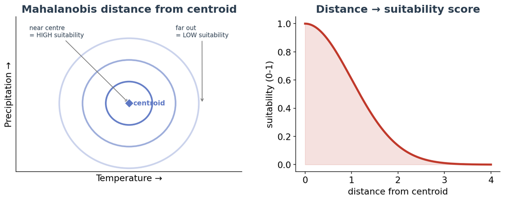

Useful arguments:

- **`newdata`** — the environment to score (our Thai raster `thai`).
- **`suitability_truncated = TRUE`** — outside the ellipsoid, force suitability to `0`, giving a clean “inside vs. outside the niche” surface.

```r
# Score every pixel for each species (returns a SpatRaster of suitability).
# We pass ALL THREE variables the niche was built on:
gen_pred <- predict(
  object                = generalist,
  newdata               = thai[[c("bio_1", "bio_4", "bio_12")]],
  suitability_truncated = TRUE
)

spec_pred <- predict(
  object                = specialist,
  newdata               = thai[[c("bio_1", "bio_4", "bio_12")]],
  suitability_truncated = TRUE
)

gen_pred   # a SpatRaster with a "suitability_trunc" layer
```

```
## class       : SpatRaster
## size        : 88, 48, 3  (nrow, ncol, nlyr)
## resolution  : 0.1666667, 0.1666667  (x, y)
## extent      : 97.5, 105.5, 5.666667, 20.33333  (xmin, xmax, ymin, ymax)
## coord. ref. : lon/lat WGS 84 (EPSG:4326)
## source(s)   : memory
## names       :  Mahalanobis,   suitability, suitability_trunc
## min values  :   0.00451254, 1.164873e-118,         0.0000000
## max values  : 543.10485787,  9.977463e-01,         0.9977463
```

**What you should see** (abridged):

```
class : SpatRaster
names : Mahalanobis, suitability, suitability_trunc
min/max of suitability_trunc : 0 , 1
```

## 3.8 Project back to the map (G-space)

Finally, plot the two suitability layers as maps with `terra::plot()`. This is the moment the abstract niche becomes a **predicted geographic distribution** — and where the generalist/specialist difference becomes obvious.

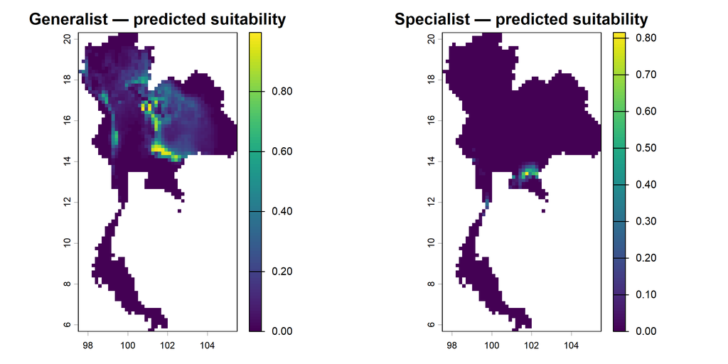

```r
par(mfrow = c(1, 2))   # show two maps side by side (1 row, 2 columns)

terra::plot(gen_pred[["suitability_trunc"]],
            main = "Generalist — predicted suitability")

terra::plot(spec_pred[["suitability_trunc"]],
            main = "Specialist — predicted suitability")
```

```r
par(mfrow = c(1, 1))   # reset the plotting layout
```

**What you should see.** The **generalist** map lights up a **large** area (it fits many places); the **specialist** is suitable only in a **small** area (few places are warm, stable, and moderately wet enough). **Take-home: broader niche → broader predicted range.**

## 3.9 (Optional) Turn a niche into virtual sightings

To connect theory to real data, `nicheR` can *sample* virtual occurrence points from a prediction with **`sample_data()`** — perfect for teaching or for testing methods (like Module B’s bias correction).

- **`n_occ`** — how many points to draw.
- **`method`** — weight points by `"suitability"` or `"mahalanobis"`.
- **`sampling`** — *where* on the niche the points land: `"centroid"` (clustered near the niche core / optimum), `"edge"` (near the tolerance boundary), or `"random"` (spread across the whole suitable area).

We draw all three from the generalist’s prediction so the difference is visible:

```r
pred_df <- as.data.frame(gen_pred, xy = TRUE)   # the prediction as a table

occ_centroid <- sample_data(n_occ = 100, prediction = pred_df,
                            prediction_layer = "suitability_trunc",
                            sampling = "centroid", method = "suitability", seed = 1)

occ_edge     <- sample_data(n_occ = 100, prediction = pred_df,
                            prediction_layer = "suitability_trunc",
                            sampling = "edge",     method = "suitability", seed = 1)

occ_random   <- sample_data(n_occ = 100, prediction = pred_df,
                            prediction_layer = "suitability_trunc",
                            sampling = "random",   method = "suitability", seed = 1)

head(occ_centroid)   # x, y coordinates of the virtual sightings
```

|  | x | y | Mahalanobis | suitability | suitability_trunc |
| --- | --- | --- | --- | --- | --- |
| 645 | 100.91667 | 18.08333 | 1.4249352 | 0.49043252 | 0.49043252 |
| 1355 | 99.25000 | 15.58333 | 1.9663427 | 0.37412275 | 0.37412275 |
| 992 | 102.75000 | 16.91667 | 2.8605482 | 0.23924334 | 0.23924334 |
| 831 | 99.91667 | 17.41667 | 5.1252059 | 0.07710378 | 0.07710378 |
| 1500 | 99.41667 | 15.08333 | 0.9451118 | 0.62340688 | 0.62340688 |
| 583 | 98.58333 | 18.25000 | 5.0208441 | 0.08123395 | 0.08123395 |

**First, see each strategy in E-space** — *how* the points sit inside the niche. Two dimensions (temperature vs. precipitation) are enough here: we pull each sample’s `bio_1` and `bio_12` values out of the `thai` raster and draw them over the niche, one panel per strategy.

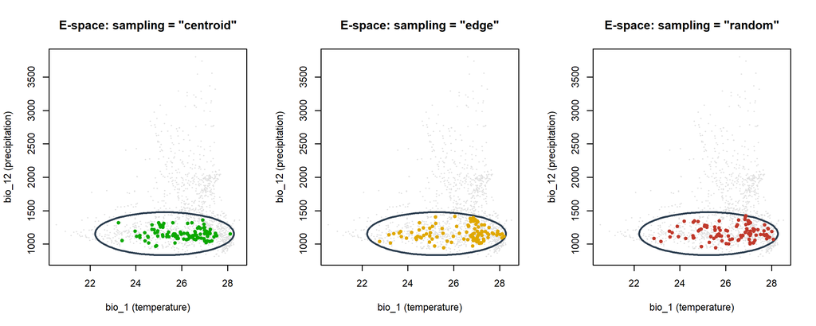

```r
# Look up bio_1 & bio_12 at each sampled location ([, -1] drops the ID column):
env_of <- function(occ) {
  terra::extract(thai[[c("bio_1", "bio_12")]], occ[, c("x", "y")])[, -1]
}

par(mfrow = c(1, 3))
for (s in list(c("centroid", "#0ba800"), c("edge", "#e0a800"), c("random", "#c0392b"))) {
  occ  <- switch(s[1], centroid = occ_centroid, edge = occ_edge, random = occ_random)
  eocc <- env_of(occ)
  plot_ellipsoid(
    generalist,
    background = back_data[, c("bio_1", "bio_12")],
    dim = c(1, 3),   # var_names are c("bio_1","bio_4","bio_12"); 1 & 3 = bio_1 vs bio_12
    col_ell = "#2c3e50", col_bg = "grey88", lwd = 2, pch = 20, cex_bg = 0.3,
    xlab = "bio_1 (temperature)", ylab = "bio_12 (precipitation)",
    main = paste0("E-space: sampling = \"", s[1], "\"")
  )
  points(eocc, pch = 20, col = s[2])
}
```

```r
par(mfrow = c(1, 1))
```

**Now the same three samples in G-space** — *where* they fall on the map:

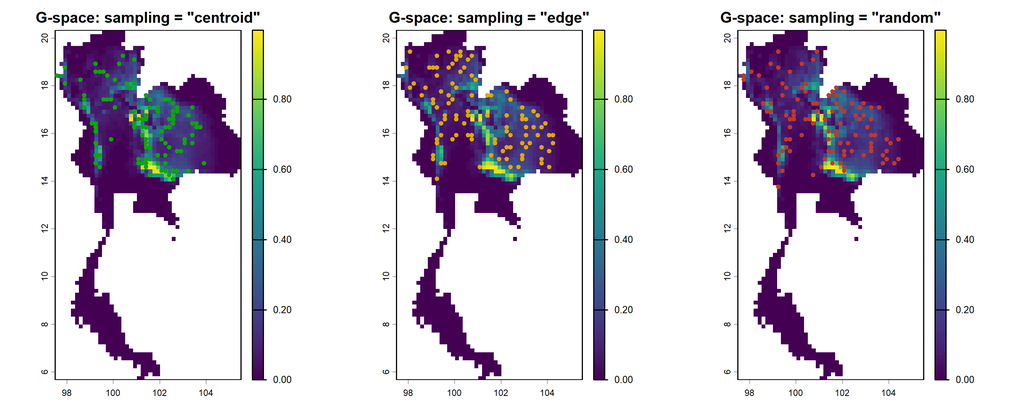

```r
par(mfrow = c(1, 3))
for (s in list(c("centroid", "#0ba800"), c("edge", "#e0a800"), c("random", "#c0392b"))) {
  occ <- switch(s[1], centroid = occ_centroid, edge = occ_edge, random = occ_random)
  terra::plot(gen_pred[["suitability_trunc"]], main = paste0("G-space: sampling = \"", s[1], "\""))
  points(occ$x, occ$y, pch = 20, col = s[2])
}
```

```r
par(mfrow = c(1, 1))
```

## 3.10 Your turn — Module A challenges

**Challenge A1.** Build a *third* species that is a **wet-forest specialist** (e.g. `bio_1` between 22 and 25 °C, `bio_4` between 60 and 110, `bio_12` between 2500 and 3700 mm). Predict and map it over Thailand. Where does it light up compared with the warm specialist?

**Challenge A2.** Widen the generalist’s precipitation range to `c(806, 3802)` (the full Thai range) and re-check `$volume`. Did the niche get bigger or smaller? Does the map agree?

**Show a hint**

Copy the `build_ellipsoid()` call, change the `range` data.frame, then reuse the `predict()` + `terra::plot()` code. Compare `$volume` before and after.

## 3.11 Module A recap

**Key points**

- A niche is an **ellipsoid** in **E-space**, built from tolerance **ranges** (`build_ellipsoid()`).
- Its **`$volume`** measures niche breadth: **generalist = large**, **specialist = small**.
- **`predict()`** scores the environment (via Mahalanobis distance); **`terra::plot()`** shows it in **G-space**.
- **The core result:** a bigger niche → a bigger predicted distribution. This single idea underlies most of niche modeling.

# 4 Module B · Fixing sampling bias with `bean` 🫛

**Learning objectives — by the end of Module B you can:**

- explain why real occurrence data are **biased**, and how bias shows up as **clusters in E-space**;
- prepare and scale occurrence data with `prepare_bean()`;
- pick an **objective** environmental grid size with `find_env_resolution()`;
- **thin** data in environmental space (`thin_env_nd()` / `thin_env_center()`);
- fit a cleaned niche and map it, and argue that thinning **improves accuracy**.

**Starting the workshop here?** Module B is fully independent of Module A — it brings its own data and its own setup chunk below. (It reuses one idea from Part 0: the **two spaces**. A one-minute look at that diagram is all you need.)

## 4.1 Why sampling bias matters

Occurrence records are rarely collected on a neat grid. They pile up where *people* go — near roads, cities, and well-studied reserves. The model then mistakes *“where scientists sampled”* for *“where the species likes to live.”* A **spatial** bias quietly becomes an **environmental** bias.

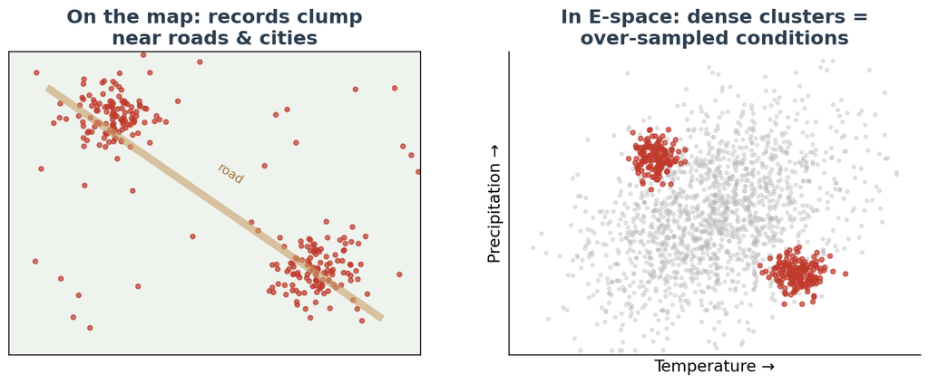

`bean`’s idea is right there in its name: divide environmental space into a grid of cells (“pods”) and keep only a limited number of points (“beans”) per cell. The result is a set of occurrences spread **evenly across the niche**, not piled up in the over-sampled corner.

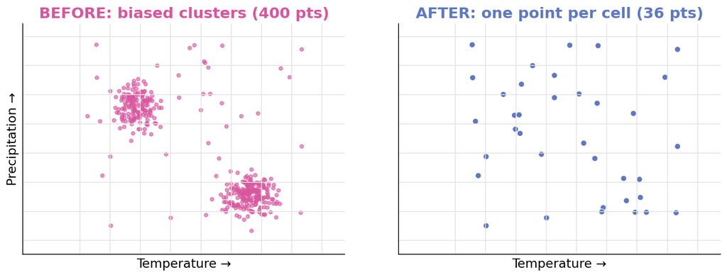

Our study species is the **Sambar deer (*Rusa unicolor*)** in **Thailand** — `bean` ships its (deliberately biased) occurrence data and Thai climate layers.

## 4.2 Setup for this module

```r
# Load the tools for Module B (install first if needed — see Part 0).
library(terra)     # for raster maps (G-space)
library(bean)      # for environmental thinning
```

## 4.3 Load and prepare the data

**`prepare_bean()`** does the cleaning in one step: it drops records with missing coordinates and **pulls the environmental values** for each occurrence out of the raster stack. Arguments:

- **`data`** — the occurrence table (must have longitude/latitude columns).
- **`env_rasters`** — the climate `SpatRaster`.
- **`longitude`, `latitude`** — the names of the coordinate columns.
- **`transform`** — how to rescale variables. `"scale"` puts every variable on a comparable footing (mean 0, sd 1), which is ideal for gridding environmental space fairly across temperature *and* precipitation.

```r
# Thai environmental layers (Geographic space) and biased deer occurrences
env <- terra::rast(system.file("extdata", "thai_env.tif",       package = "bean"))
occ <- read.csv(     system.file("extdata", "Rusa_unicolor.csv", package = "bean"))

# Clean + attach environment + scale variables
prepared <- prepare_bean(
  data        = occ,
  env_rasters = env,
  longitude   = "x",
  latitude    = "y",
  transform   = "scale"
)

head(prepared)   # coordinates + scaled bio_1, bio_12, bio_15, bio_4
```

|  | species | y | x | bio_1 | bio_12 | bio_15 | bio_4 |
| --- | --- | --- | --- | --- | --- | --- | --- |
| 1 | Rusa unicolor | 15.37239 | 99.11555 | -1.6909295 | 0.003511156 | -0.2454693 | -0.2573387 |
| 2 | Rusa unicolor | 15.41415 | 99.28763 | -0.8711075 | -0.267821213 | -0.3053829 | -0.1768698 |
| 3 | Rusa unicolor | 14.46838 | 101.22005 | -1.3879976 | -0.534812263 | -0.3835742 | -0.2876102 |
| 4 | Rusa unicolor | 15.65606 | 99.31600 | -0.6288324 | -0.224408034 | -0.2390396 | -0.0834852 |
| 5 | Rusa unicolor | 14.39543 | 101.41694 | -2.0311866 | -0.604273349 | -0.5074636 | -0.1398570 |
| 6 | Rusa unicolor | 12.72500 | 100.88947 | 1.0537073 | -0.311234392 | -0.6623129 | -1.0746857 |

**What you should see** (abridged): a table with the occurrence coordinates plus their scaled climate values (roughly −3 to +3):

[output not shown]

## 4.4 See the original data & its bias

Before touching anything, let’s *look* at the raw records — first on the map, then in environmental space.

**On the map (G-space):** the Sambar deer records plotted over Thai temperature. Notice how they **clump** in a few areas instead of covering the country evenly.

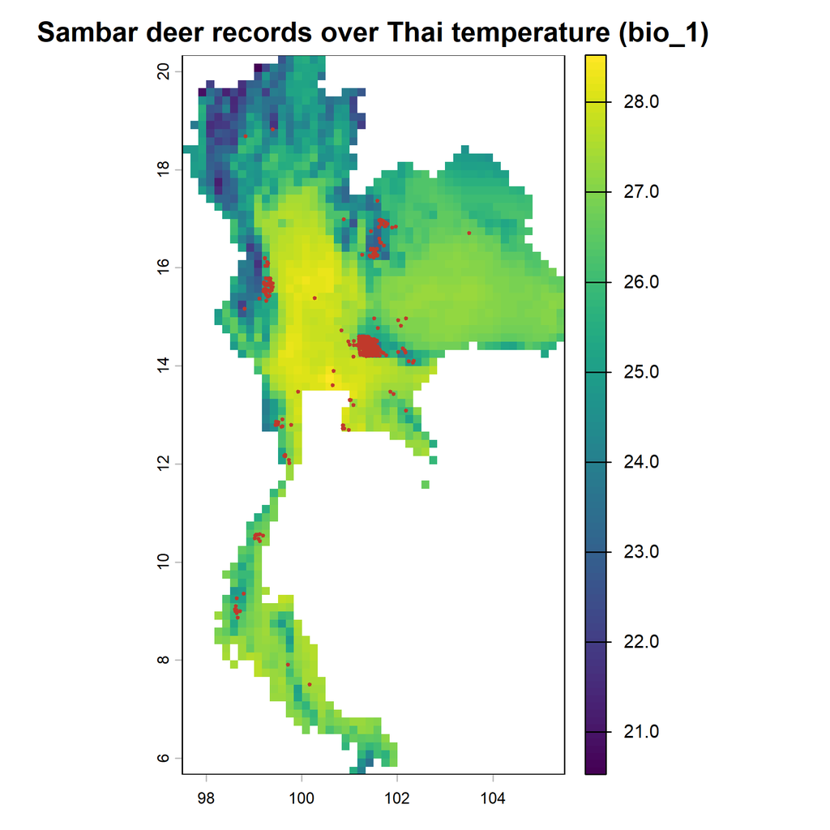

```r
terra::plot(env[["bio_1"]], main = "Sambar deer records over Thai temperature (bio_1)")
points(prepared$x, prepared$y, pch = 20, cex = 0.5, col = "#c0392b")
```

**In environmental space (E-space):** that spatial clumping becomes **dense clusters** — the exact conditions the model would otherwise over-learn.

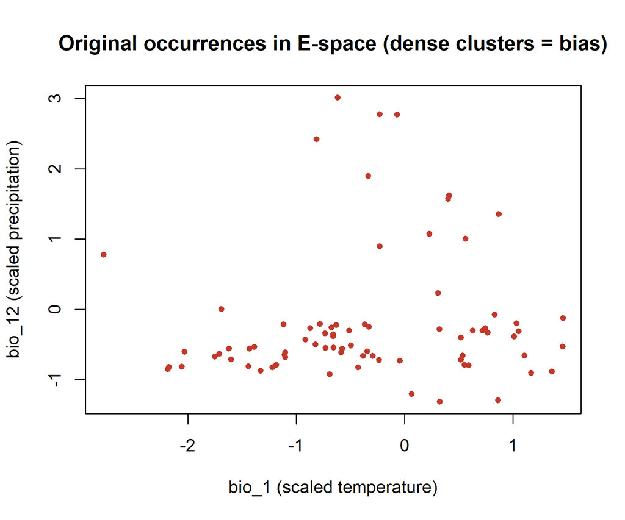

```r
plot(prepared[, c("bio_1", "bio_12")],
     pch = 20, col = "#c0392b",
     xlab = "bio_1 (scaled temperature)",
     ylab = "bio_12 (scaled precipitation)",
     main = "Original occurrences in E-space (dense clusters = bias)")
```

**What you should see.** On the map, red points bunch in a few regions rather than spreading evenly. In E-space, tight knots of points mark the over-sampled environments — the bias we are about to thin out.

## 4.5 Step 1 — Choose an objective grid resolution

How big should each environmental grid cell (“pod”) be? Instead of guessing, **`find_env_resolution()`** picks a statistically defensible cell size from the data using a **kernel-density bandwidth** (the scale at which the cloud of points becomes “smooth”). Arguments:

- **`data`** — the prepared occurrences.
- **`env_vars`** — which variables define the environmental grid.
- **`method`** — the bandwidth rule: `"sheather-jones"` (default, recommended), `"silverman"`, or `"scott"`.

```r
res <- find_env_resolution(
  data     = prepared,
  env_vars = c("bio_1", "bio_12"),
  method   = "sheather-jones"
)

res$suggested_resolution   # the suggested cell size (one number per variable)
```

```
##       bio_1      bio_12
## 0.056162684 0.004615848
```

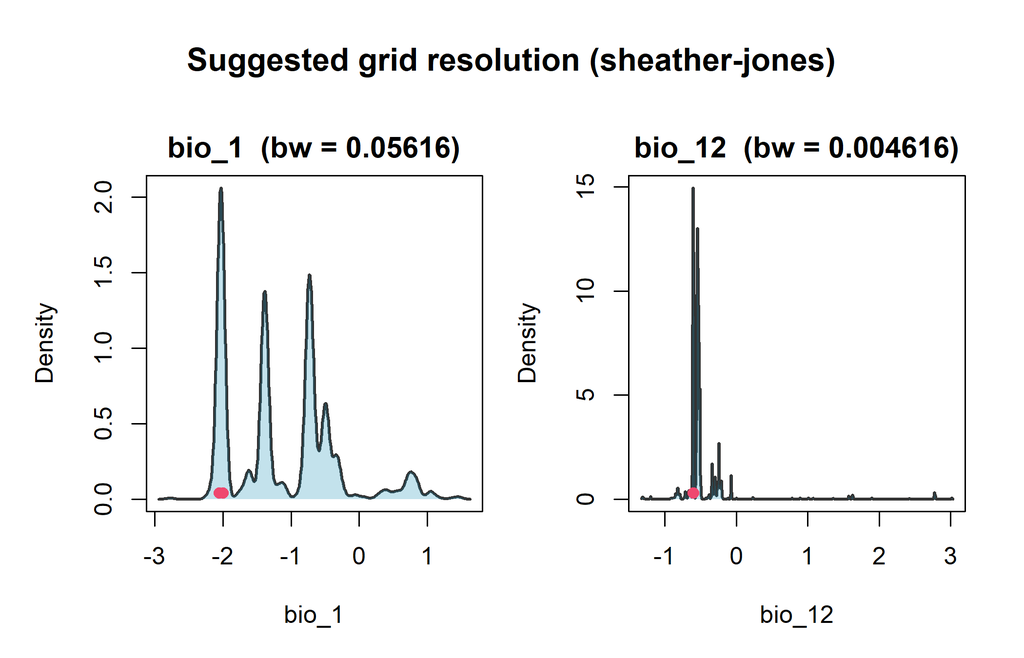

```r
plot(res)                  # a diagnostic plot of the density / among-point distances
```

**What you should see** — one suggested cell edge length per variable, e.g.:

[output not shown]

The grid size is read from the *shape of the data*, not chosen by hand.

## 4.6 Step 2 — Thin the data in environmental space

Now we apply the thinning. `bean` offers two flavours:

- **`thin_env_nd()` — *stochastic*:** randomly keeps **one** real point from each occupied cell. Preserves real records.
- **`thin_env_center()` — *deterministic*:** replaces the points in each occupied cell with a single point at the **cell centre**. Fully reproducible.

Shared arguments: **`env_vars`**, **`grid_resolution`** (use the value from Step 1), and (for the stochastic method) a **`seed`** for reproducibility.

```r
# Stochastic thinning: keep one real occurrence per occupied environmental cell
thinned <- thin_env_nd(
  data            = prepared,
  env_vars        = c("bio_1", "bio_12"),
  grid_resolution = res$suggested_resolution,   # objective cell size from Step 1
  seed            = 123
)

# Deterministic alternative (one point at the centre of each occupied cell)
thinned_center <- thin_env_center(
  data            = prepared,
  env_vars        = c("bio_1", "bio_12"),
  grid_resolution = res$suggested_resolution
)

print(thinned)   # how many points were kept?
```

```
## --- Bean Stochastic Thinning Results ---
##
## Thinned 1024 original points to 78 points.
## This represents a retention of 7.6% of the data.
##
## --------------------------------------
```

**What you should see:**

[output not shown]

The retained records live in **`thinned$thinned_data`**; the counts are in `thinned$n_original` and `thinned$n_thinned`.

## 4.7 Step 3 — See the thinned data, then compare

**The thinned data on its own** — the same species, but with the clustering removed so the points spread evenly across environmental space:

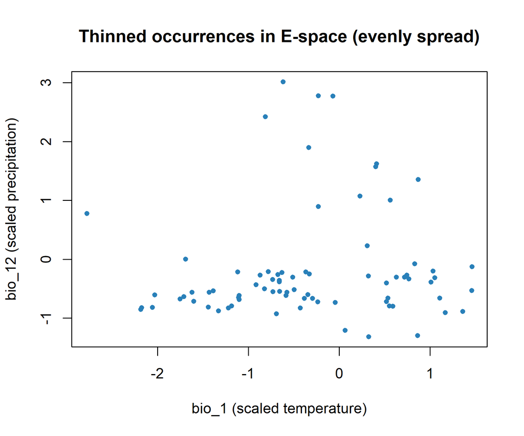

```r
plot(thinned$thinned_data[, c("bio_1", "bio_12")],
     pch = 20, col = "#2980b9",
     xlab = "bio_1 (scaled temperature)",
     ylab = "bio_12 (scaled precipitation)",
     main = "Thinned occurrences in E-space (evenly spread)")
```

**Original vs. thinned, overlaid.** **`plot_bean()`** draws the **original** (biased) points and the **thinned** points together so the effect is obvious. It needs the original data, the thinned object, and the variables to display.

[figure not shown]

```r
plot_bean(
  original_data  = prepared,
  thinned_object = thinned,
  env_vars       = c("bio_1", "bio_12")
)
```

## 4.8 Step 4 — Fit the niche: original vs. cleaned data

To see what the bias correction buys us, we fit an ellipsoid niche **twice** with **`fit_ellipsoid()`** — first on the **original (biased)** occurrences, then on the **thinned** ones. Arguments:

- **`data`** — the occurrences to fit (`prepared`, or `thinned$thinned_data`).
- **`env_vars`** — the niche variables.
- **`method`** — `"covmat"` (classical covariance, default) or `"mve"` (robust minimum-volume ellipsoid, resistant to outliers).
- **`level`** — confidence level enclosed by the ellipse (e.g. `0.95`).

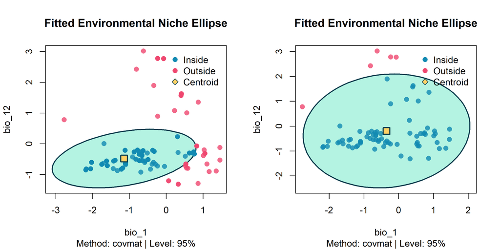

```r
# Fit on the ORIGINAL (biased) data:
fit_original <- fit_ellipsoid(
  data     = prepared,
  env_vars = c("bio_1", "bio_12"),
  method   = "covmat",
  level    = 0.95
)

# Fit on the THINNED (bias-corrected) data:
fit_thinned <- fit_ellipsoid(
  data     = thinned$thinned_data,
  env_vars = c("bio_1", "bio_12"),
  method   = "covmat",
  level    = 0.95
)

# Compare the two fitted ellipses (left = original, right = thinned):
par(mfrow = c(1, 2))
plot(fit_original)
plot(fit_thinned)
```

```r
par(mfrow = c(1, 1))
```

**What you should see.** Two fitted ellipses. The **original** fit (left) is pulled toward the over-sampled cluster, so its centre and tilt reflect the sampling effort. The **thinned** fit (right) sits more evenly over the species’ true environmental range.

## 4.9 Step 5 — Project the niches to suitability maps

A neat design feature: a `bean` niche also carries `nicheR`’s class, so once `nicheR` is loaded, its **`predict()`** method works on the `bean` object directly — no conversion needed. We project **both** niches onto the Thai raster: the original (biased) fit **first**, then the thinned one.

**Note on units.** Because we scaled the variables in `prepare_bean()`, the raster must be on the *same* scale before predicting (`scale(env...)`) — **or** run the whole module with `transform = "none"` to keep raw units and project directly. If your map looks odd, this mismatch is the usual cause.

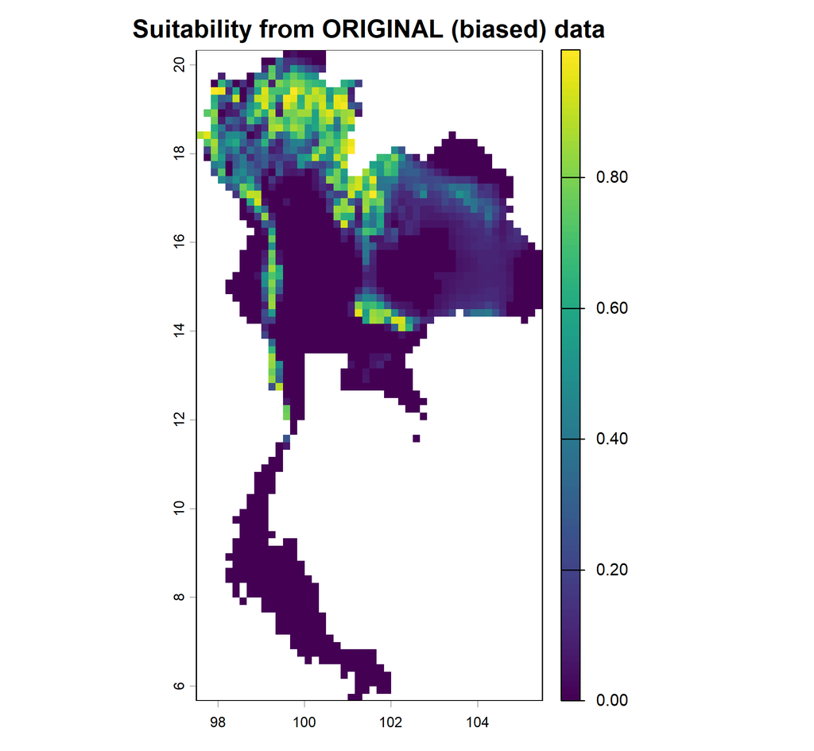

```r
library(nicheR)   # provides the predict() method for bean ellipsoids

env_s <- scale(env[[c("bio_1", "bio_12")]])   # match the scaling used to fit

# 1) ORIGINAL (biased) niche:
suit_original <- predict(fit_original, newdata = env_s, suitability_truncated = TRUE)
terra::plot(suit_original[["suitability_trunc"]],
            main = "Suitability from ORIGINAL (biased) data")
```

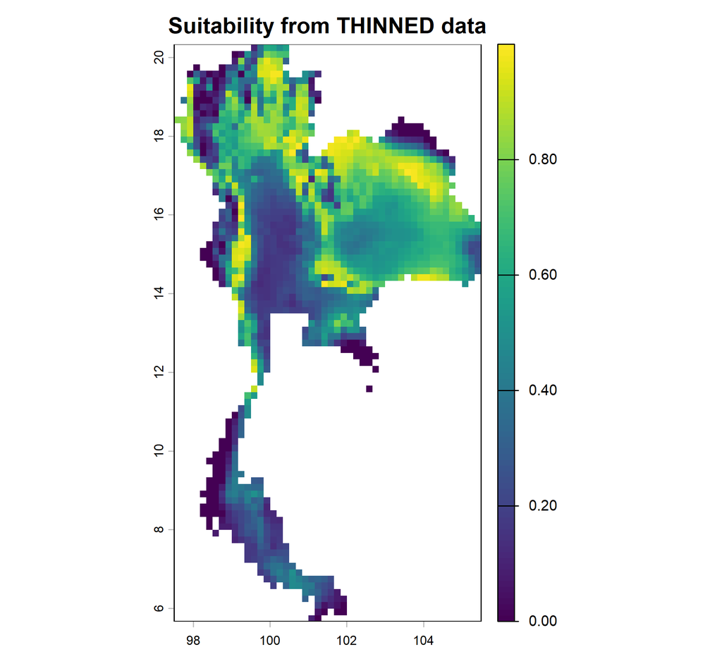

```r
# 2) THINNED (bias-corrected) niche:
suit_thinned <- predict(fit_thinned, newdata = env_s, suitability_truncated = TRUE)
terra::plot(suit_thinned[["suitability_trunc"]],
            main = "Suitability from THINNED data")
```

**What you should see.** Two maps of Thailand, in order: first the suitability predicted from the **original biased** niche, then from the **thinned** one. The biased map leans toward the over-sampled climates; the thinned map is more even.

## 4.10 Step 6 — Compare the maps: with vs. without thinning

The final question: **does removing the bias change the predicted map?** We already fitted both niches (Step 4) and projected both (Step 5), so here we simply place the two suitability surfaces — `suit_original` and `suit_thinned` — side by side in G-space.

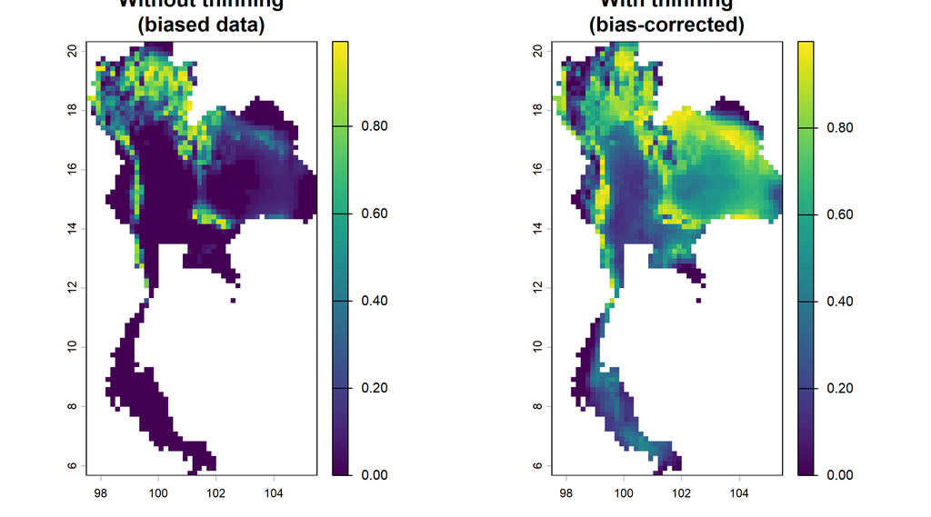

```r
# Reuse the two projections made in Step 5, side by side:
par(mfrow = c(1, 2))
terra::plot(suit_original[["suitability_trunc"]],
            main = "Without thinning\n(biased data)")
terra::plot(suit_thinned[["suitability_trunc"]],
            main = "With thinning\n(bias-corrected)")
```

```r
par(mfrow = c(1, 1))
```

**What you should see.** Two maps of Thailand. The **without-thinning** map is pulled toward the climates that were over-sampled, so it over- or under-predicts suitability in places. The **with-thinning** map is more even and honest, because the niche was estimated from points spread across the whole environmental range. Same species, same landscape — the only difference is whether we corrected the sampling bias.